# Assignment 4

Vdovenko Anton

7/14/2020

# Purpose of Visualisation

The sinking of the Titanic is one of the most infamous shipwrecks in history, due to large scale of causalities and publicity this catastrophe got. The main goal is to show how different features affected **survivability**.

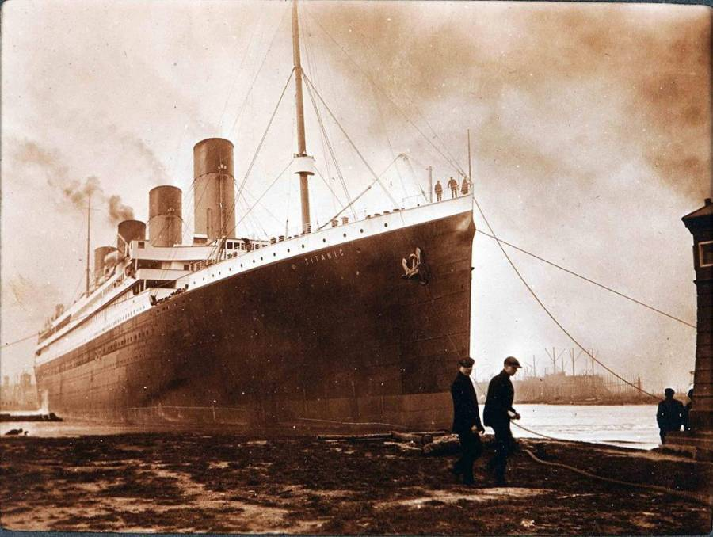

## The Titanic Data Dictionary.

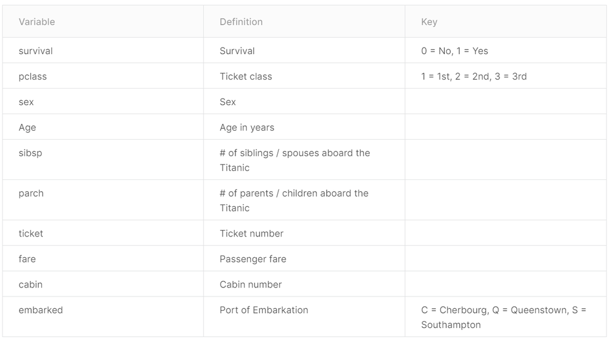

# Visualisation Step-by Step

## Load Libraries

```r
library(tidyverse)
library(alluvial)
```

Tidyverse is a set of libraries for data upload/cleaning/wrangling/visualisation.  
Alluvial is a library for Alluvial diagram which is a variant of a Parallel Coordinates Plot (PCP) but for categorical variables.

## Data upload

```r
df = read_csv("titanic.csv")
show(df)
```

```
## # A tibble: 891 x 12
##    PassengerId Survived Pclass Name  Sex     Age SibSp Parch Ticket  Fare Cabin
##          <dbl>    <dbl>  <dbl> <chr> <chr> <dbl> <dbl> <dbl> <chr>  <dbl> <chr>
##  1           1        0      3 Brau~ male     22     1     0 A/5 2~  7.25 <NA>
##  2           2        1      1 Cumi~ fema~    38     1     0 PC 17~ 71.3  C85
##  3           3        1      3 Heik~ fema~    26     0     0 STON/~  7.92 <NA>
##  4           4        1      1 Futr~ fema~    35     1     0 113803 53.1  C123
##  5           5        0      3 Alle~ male     35     0     0 373450  8.05 <NA>
##  6           6        0      3 Mora~ male     NA     0     0 330877  8.46 <NA>
##  7           7        0      1 McCa~ male     54     0     0 17463  51.9  E46
##  8           8        0      3 Pals~ male      2     3     1 349909 21.1  <NA>
##  9           9        1      3 John~ fema~    27     0     2 347742 11.1  <NA>
## 10          10        1      2 Nass~ fema~    14     1     0 237736 30.1  <NA>
## # ... with 881 more rows, and 1 more variable: Embarked <chr>
```

## Missing Values

First lets be mindfull of data restrictions we may have. As can be seen above we have missing values in our data lets check what they are.

Total number of missing values

```r
sum(is.na(df))
```

```
## [1] 866
```

Missing values by columns

```r
df %>% summarise(
  Survived = sum(is.na(Survived)),
  Pclass = sum(is.na(Pclass)),
  Name = sum(is.na(Name)),
  Sex = sum(is.na(Sex)),
  Age = sum(is.na(Age)),
  SibSp = sum(is.na(SibSp)),
  Fare = sum(is.na(Fare)),
  Cabin = sum(is.na(Cabin)),
  Embarked = sum(is.na(Embarked))
)
```

```
## # A tibble: 1 x 9
##   Survived Pclass  Name   Sex   Age SibSp  Fare Cabin Embarked
##      <int>  <int> <int> <int> <int> <int> <int> <int>    <int>
## 1        0      0     0     0   177     0     0   687        2
```

Lets replace misisng values in Age columns with median

```r
df = df %>%
  mutate_at(vars(Age), ~ifelse(is.na(.), median(., na.rm = TRUE), .))

df %>% summarise(
  Age = sum(is.na(Age))
)
```

```
## # A tibble: 1 x 1
##     Age
##   <int>
## 1     0
```

For graphs purposses lets make sex values in capital letters.

```r
df$Sex[df$Sex == "female"] = "Female"
df$Sex[df$Sex == "male"] = "Male"
```

## Deaths/Survived

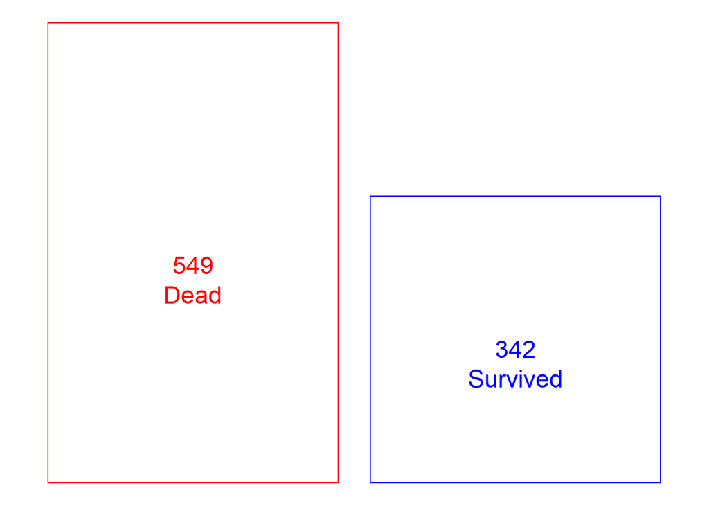

```r
ggplot(data = df, aes(x = factor(Survived))) + geom_bar(stat = "count", color = c("red","blue"), fill = "white")+
  geom_text(stat='count', aes(label=..count..), vjust=c(14,9), color=c("red","blue"), size=6)+
  annotate(geom="text", x=1.00, y = 225, label="Dead",
              color="red", size = 6)+
  annotate(geom="text", x=2.00, y = 125, label="Survived",
              color="blue", size = 6)+
  theme_void()
```

As can be seen from the graph more than half of passengers had died during shipwrecked.

## Age/Survived

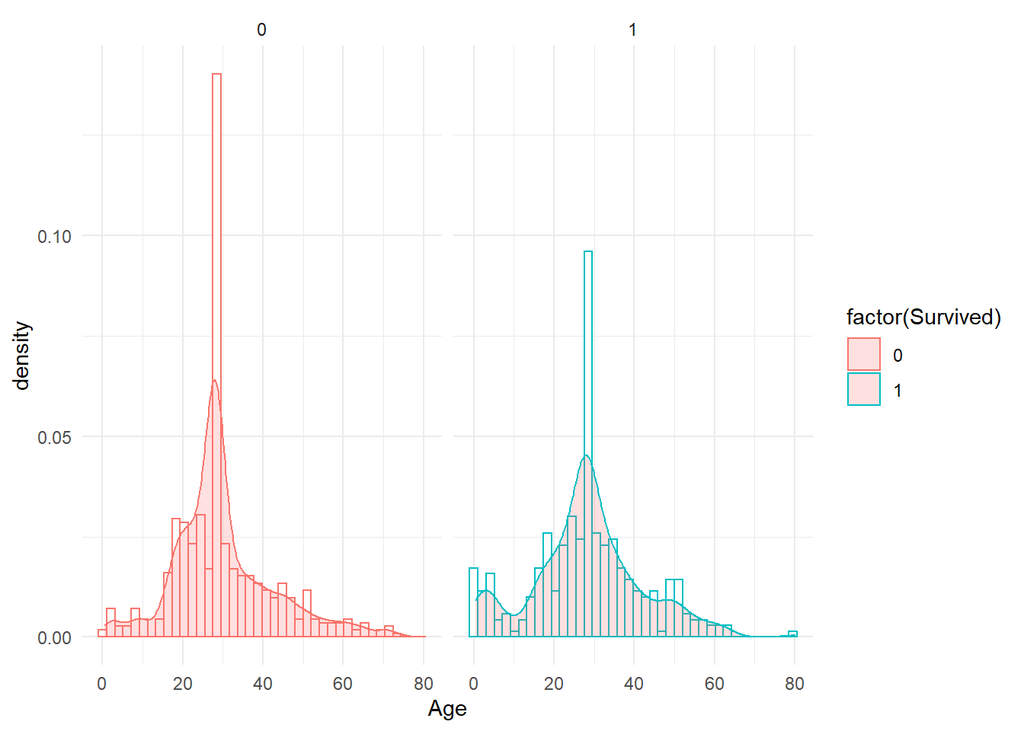

```r
ggplot(data = df, aes(x=Age, color = factor(Survived)))+
  geom_histogram(aes(y=..density..),fill="white", bins = 40)+
  geom_density(alpha=.2, fill="#FF6666")+
  facet_grid(~Survived)+
  theme_minimal()
```

One intake we can have from this one is that kids below 10 years old seemed to have higher chances to survive than other age groups.

## Sex/Survived

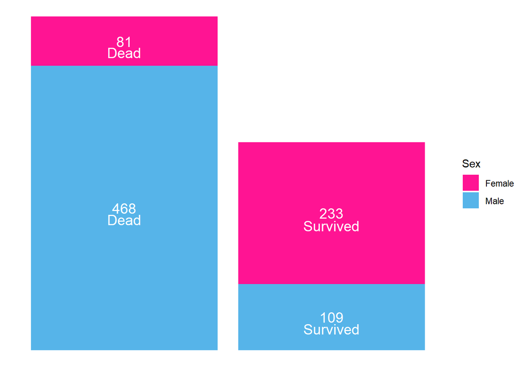

```r
ggplot(data = df, aes(x = factor(Survived), fill = Sex)) + geom_bar(stat = "count")+
  geom_text(aes(label=..count..),stat="count",position=position_stack(0.5), color = "white", size = 5) +
  scale_fill_manual("Sex", values = c("Female" = "deeppink", "Male" = "#56B4E9")) +
  annotate(geom="text", x=1.00, y = 215, label="Dead",color="white", size = 5)+
  annotate(geom="text", x=1.00, y = 490, label="Dead",color="white", size = 5)+
  annotate(geom="text", x=2.00, y = 35, label="Survived",color="white", size = 5)+
  annotate(geom="text", x=2.00, y = 205, label="Survived",color="white", size = 5)+
  theme_void()
```

Chance for a male to survive = 109/(468 + 109) = **19%**.

Chance for a female to survive = 233/(233 + 81) = **74%**.

## Pclass ordinal scale

Pclass has ordinal scale, and we need to check the order of values.

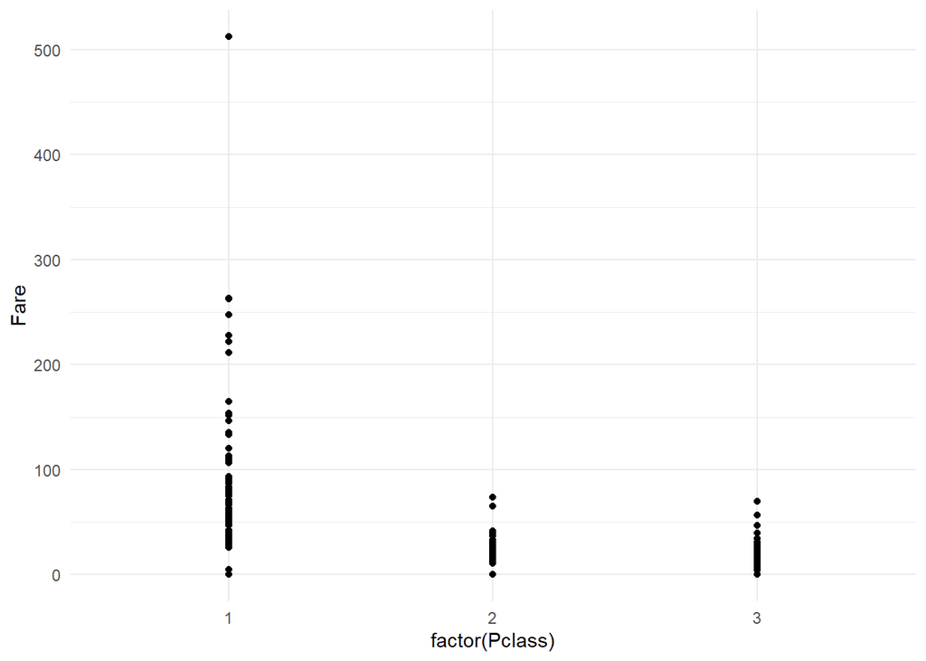

```r
ggplot(data = df, aes(y = Fare, x = factor(Pclass))) + geom_point() + theme_minimal()
```

From graph we can infer that **1 > 2 > 3**, it will help us understand better either or not there is any relation of surviability with Pclass.

## Pclass/Survived

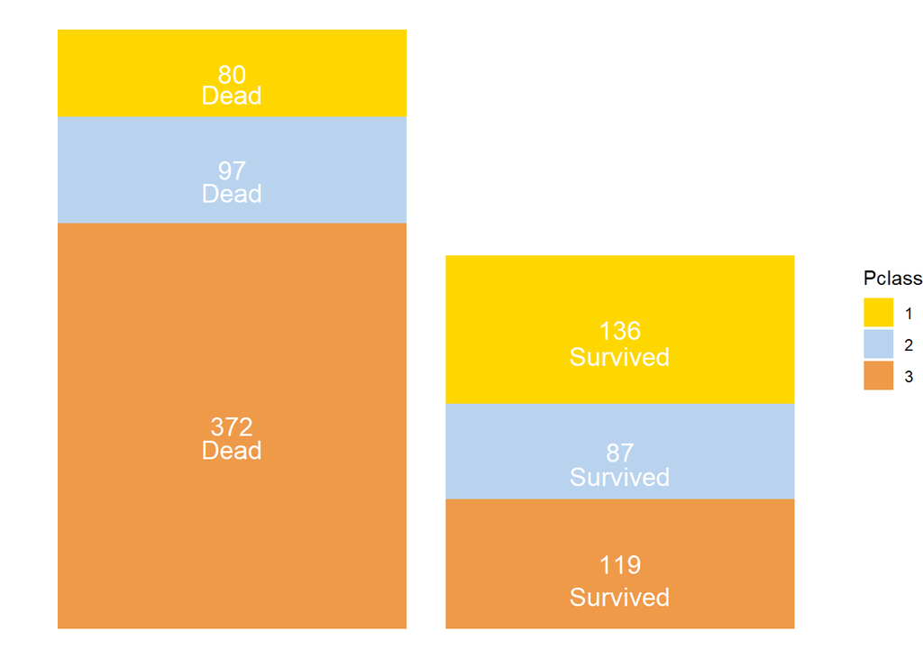

```r
ggplot(data = df, aes(x = factor(Survived), fill = factor(Pclass))) + geom_bar(stat = "count") +
  geom_text(aes(label=..count..),stat="count",position=position_stack(0.5), color = "white", size = 5) +
  scale_fill_manual("Pclass", values = c("1" = "gold", "2" = "slategray2", "3" = "tan2"))+
  annotate(geom="text", x=1.00, y = 490, label="Dead",color="white", size = 5)+
  annotate(geom="text", x=1.00, y = 400, label="Dead",color="white", size = 5)+
  annotate(geom="text", x=1.00, y = 165, label="Dead",color="white", size = 5)+
  annotate(geom="text", x=2.00, y = 250, label="Survived",color="white", size = 5)+
  annotate(geom="text", x=2.00, y = 140, label="Survived",color="white", size = 5)+
  annotate(geom="text", x=2.00, y = 30, label="Survived",color="white", size = 5)+
  theme_void()
```

Chance for a first class ticket passenger to survive = 136/(136+80) = **63%**

Chance for a second class ticket passenger to survive = 87/(97+87) = **47%**

Chance for a third class ticket passenger to survive = 119/(372+119) = **24%**

As we can see that having higher class ticket affects survivability drasticly.

## Sex/Pclass/Survived

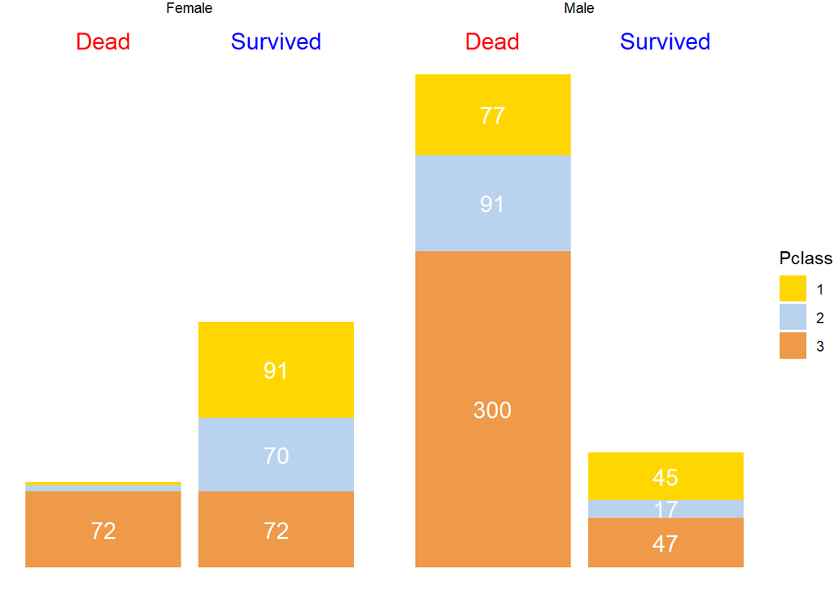

```r
ggplot(data = df, aes(x = factor(Survived), fill = factor(Pclass))) + geom_bar(stat = "count") + facet_grid(~Sex)+
  geom_text(aes(label=ifelse(..count.. < 10, "",..count..)),stat="count",position=position_stack(0.5), color = "white", size = 5) +
  scale_fill_manual("Pclass", values = c("1" = "gold", "2" = "slategray2", "3" = "tan2")) +
  annotate(geom="text", x=1.00, y = 500, label="Dead",color="Red", size = 5)+
  annotate(geom="text", x=2.00, y = 500, label="Survived",color="Blue", size = 5)+
  theme_void()
```

For a female:

- Chance for a first class ticket passenger to survive = 91/(91+3) = **97%**
- Chance for a second class ticket passenger to survive = 70/(6+70) **92%**
- Chance for a third class ticket passenger to survive = 72/(72+72) = **50%**

For a male:

- Chance for a first class ticket passenger to survive = 45/(77+45) = **37%**
- Chance for a second class ticket passenger to survive = 17/(91+17) = **16%**
- Chance for a third class ticket passenger to survive = 47/(47+300) = **13.5%**

## Alluvial Plot

```r
# Prepare data for alluvial plot
tab = read.csv("Cross_tab.csv")
colnames(tab) = c("Pclass","Survived","Sex","Freq")
tab = tab[c("Pclass","Sex","Survived","Freq")]
colnames(tab)
```

```
## [1] "Pclass"   "Sex"      "Survived" "Freq"
```

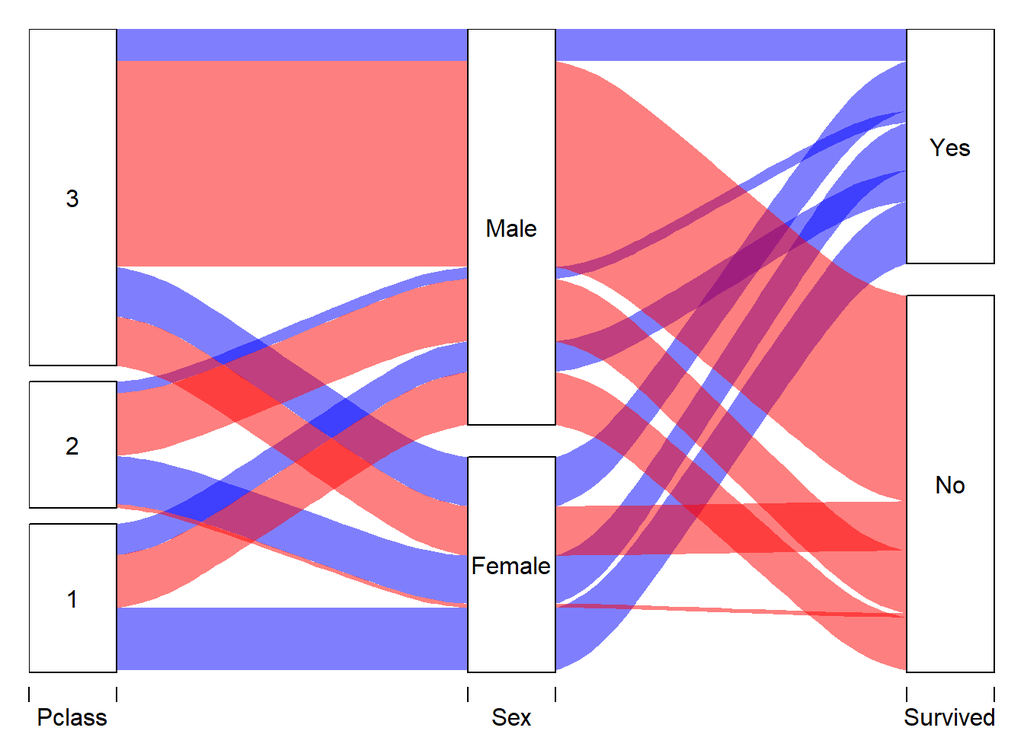

```r
alluvial( tab[,1:3], freq=tab$Freq, border=NA,
         hide = tab$Freq < quantile(tab$Freq, .0001),
         col=ifelse( tab$Survived == "No", "red", "blue") )
```

The Alluvial Diagramm give us summarized picture of what we have observed in graphs above, but in one comprehensive picture.

# Conclusion

Through the EDA we drill down to the two main factor wich affect survivability in titanic catastrophe **Sex** and **Ticket Class**.